# Starbucks Capstone Challenge

### Project Overview

In the project, I will try to figure how the customers of starbucks are using the app and the current scenario in giving offers.I will also try to figure out whom should the app consider for promotion.Here I am given datasets on customer behaviour in using the Starbucks reward app,using it we can understand the customer behaviour and make better decisions

## Problem

As a business owner I dont want to give every customer our offers,I would like to offer only those who are liable to complete it.Because giving an offer to every person will be a waste of time and resources ,and that time and resources can be utilized in something other,so I should give offer to those who are the most trusted and valuable customers and we know that they will complete it.I am going to solve the problem first by cleaning the data,then performing analysis and then find out who are my valuable customers.

## Analysis

### Business understanding

Here my focus is to find the patterns and show when and where to give the customer the offer and which type of offer.The main aim is to provide answers of thr questions with the Data Visualizations.The data used is provided by the starbucks.

### Data Exploration

We have three files given in the project.Before startting we need to look what is the data and explore it.We need to look whether the data is noisy,if it is noisy we will remove it.If there are Nan values then we need to fill the right value or remove it.We need to look after the data types of columns and correct if there is a wrong one.

```python
# import libraries
import pandas as pd
import numpy as np
from sklearn.preprocessing import MultiLabelBinarizer
import json
import math
import plotly
import plotly.graph_objs as go
import matplotlib.pyplot as plt
import seaborn as sns
plotly.offline.init_notebook_mode()
%matplotlib inline
```

```python
# read in the json files
portfolio = pd.read_json('portfolio.json', orient='records', lines=True)
profile = pd.read_json('profile.json', orient='records', lines=True)
transcript = pd.read_json('transcript.json', orient='records', lines=True)
```

### Data understanding

The data is contained in three files:

- portfolio.json - containing offer ids and meta data about each offer (duration, type, etc.)
- profile.json - demographic data for each customer
- transcript.json - records for transactions, offers received, offers viewed, and offers completed

Here is the schema and explanation of each variable in the files:

**portfolio.json**

- id (string) - offer id
- offer_type (string) - type of offer ie BOGO, discount, informational
- difficulty (int) - minimum required spend to complete an offer
- reward (int) - reward given for completing an offer
- duration (int) - time for offer to be open, in days
- channels (list of strings)

```python
portfolio.head()
```

|  | reward | channels | difficulty | duration | offer_type | id |
| --- | --- | --- | --- | --- | --- | --- |
| 0 | 10 | [email, mobile, social] | 10 | 7 | bogo | ae264e3637204a6fb9bb56bc8210ddfd |
| 1 | 10 | [web, email, mobile, social] | 10 | 5 | bogo | 4d5c57ea9a6940dd891ad53e9dbe8da0 |
| 2 | 0 | [web, email, mobile] | 0 | 4 | informational | 3f207df678b143eea3cee63160fa8bed |
| 3 | 5 | [web, email, mobile] | 5 | 7 | bogo | 9b98b8c7a33c4b65b9aebfe6a799e6d9 |
| 4 | 5 | [web, email] | 20 | 10 | discount | 0b1e1539f2cc45b7b9fa7c272da2e1d7 |

```python
portfolio.shape
```

```
(10, 6)
```

**profile.json**

- age (int) - age of the customer
- became_member_on (int) - date when customer created an app account
- gender (str) - gender of the customer (note some entries contain 'O' for other rather than M or F)
- id (str) - customer id
- income (float) - customer's income

```python
profile.head()
```

|  | gender | age | id | became_member_on | income |
| --- | --- | --- | --- | --- | --- |
| 0 | None | 118 | 68be06ca386d4c31939f3a4f0e3dd783 | 20170212 | NaN |
| 1 | F | 55 | 0610b486422d4921ae7d2bf64640c50b | 20170715 | 112000.0 |
| 2 | None | 118 | 38fe809add3b4fcf9315a9694bb96ff5 | 20180712 | NaN |
| 3 | F | 75 | 78afa995795e4d85b5d9ceeca43f5fef | 20170509 | 100000.0 |
| 4 | None | 118 | a03223e636434f42ac4c3df47e8bac43 | 20170804 | NaN |

```python
profile.shape
```

```
(17000, 5)
```

**transcript.json**

- event (str) - record description (ie transaction, offer received, offer viewed, etc.)
- person (str) - customer id
- time (int) - time in hours since start of test. The data begins at time t=0
- value - (dict of strings) - either an offer id or transaction amount depending on the record

```python
transcript.head()
```

|  | person | event | value | time |
| --- | --- | --- | --- | --- |
| 0 | 78afa995795e4d85b5d9ceeca43f5fef | offer received | {'offer id': '9b98b8c7a33c4b65b9aebfe6a799e6d9'} | 0 |
| 1 | a03223e636434f42ac4c3df47e8bac43 | offer received | {'offer id': '0b1e1539f2cc45b7b9fa7c272da2e1d7'} | 0 |
| 2 | e2127556f4f64592b11af22de27a7932 | offer received | {'offer id': '2906b810c7d4411798c6938adc9daaa5'} | 0 |
| 3 | 8ec6ce2a7e7949b1bf142def7d0e0586 | offer received | {'offer id': 'fafdcd668e3743c1bb461111dcafc2a4'} | 0 |
| 4 | 68617ca6246f4fbc85e91a2a49552598 | offer received | {'offer id': '4d5c57ea9a6940dd891ad53e9dbe8da0'} | 0 |

```python
transcript.shape
```

```
(306534, 4)
```

### Data Wrangling/Data Preprocessing

```python
portfolio
```

|  | reward | channels | difficulty | duration | offer_type | id |
| --- | --- | --- | --- | --- | --- | --- |
| 0 | 10 | [email, mobile, social] | 10 | 7 | bogo | ae264e3637204a6fb9bb56bc8210ddfd |
| 1 | 10 | [web, email, mobile, social] | 10 | 5 | bogo | 4d5c57ea9a6940dd891ad53e9dbe8da0 |
| 2 | 0 | [web, email, mobile] | 0 | 4 | informational | 3f207df678b143eea3cee63160fa8bed |
| 3 | 5 | [web, email, mobile] | 5 | 7 | bogo | 9b98b8c7a33c4b65b9aebfe6a799e6d9 |
| 4 | 5 | [web, email] | 20 | 10 | discount | 0b1e1539f2cc45b7b9fa7c272da2e1d7 |
| 5 | 3 | [web, email, mobile, social] | 7 | 7 | discount | 2298d6c36e964ae4a3e7e9706d1fb8c2 |
| 6 | 2 | [web, email, mobile, social] | 10 | 10 | discount | fafdcd668e3743c1bb461111dcafc2a4 |
| 7 | 0 | [email, mobile, social] | 0 | 3 | informational | 5a8bc65990b245e5a138643cd4eb9837 |
| 8 | 5 | [web, email, mobile, social] | 5 | 5 | bogo | f19421c1d4aa40978ebb69ca19b0e20d |
| 9 | 2 | [web, email, mobile] | 10 | 7 | discount | 2906b810c7d4411798c6938adc9daaa5 |

```python
portfolio.dtypes
```

```
reward         int64
channels      object
difficulty     int64
duration       int64
offer_type    object
id            object
dtype: object
```

Here channel column has list of items,I will use MultiLabelBinarizer same like one hot emcoding to change it.

```python
changer = MultiLabelBinarizer()
df = pd.DataFrame(changer.fit_transform(portfolio['channels']),
                   columns=changer.classes_,
                   index=portfolio['channels'].index)
portfolio = portfolio.drop('channels', axis=1)
portfolio = pd.concat([portfolio, df], axis=1, sort=False)
portfolio
```

|  | reward | difficulty | duration | offer_type | id | email | mobile | social | web |
| --- | --- | --- | --- | --- | --- | --- | --- | --- | --- |
| 0 | 10 | 10 | 7 | bogo | ae264e3637204a6fb9bb56bc8210ddfd | 1 | 1 | 1 | 0 |
| 1 | 10 | 10 | 5 | bogo | 4d5c57ea9a6940dd891ad53e9dbe8da0 | 1 | 1 | 1 | 1 |
| 2 | 0 | 0 | 4 | informational | 3f207df678b143eea3cee63160fa8bed | 1 | 1 | 0 | 1 |
| 3 | 5 | 5 | 7 | bogo | 9b98b8c7a33c4b65b9aebfe6a799e6d9 | 1 | 1 | 0 | 1 |
| 4 | 5 | 20 | 10 | discount | 0b1e1539f2cc45b7b9fa7c272da2e1d7 | 1 | 0 | 0 | 1 |
| 5 | 3 | 7 | 7 | discount | 2298d6c36e964ae4a3e7e9706d1fb8c2 | 1 | 1 | 1 | 1 |
| 6 | 2 | 10 | 10 | discount | fafdcd668e3743c1bb461111dcafc2a4 | 1 | 1 | 1 | 1 |
| 7 | 0 | 0 | 3 | informational | 5a8bc65990b245e5a138643cd4eb9837 | 1 | 1 | 1 | 0 |
| 8 | 5 | 5 | 5 | bogo | f19421c1d4aa40978ebb69ca19b0e20d | 1 | 1 | 1 | 1 |
| 9 | 2 | 10 | 7 | discount | 2906b810c7d4411798c6938adc9daaa5 | 1 | 1 | 0 | 1 |

```python
portfolio.isnull().sum()
```

```
reward        0
difficulty    0
duration      0
offer_type    0
id            0
email         0
mobile        0
social        0
web           0
dtype: int64
```

No null values in portfolio

```python
profile.head()
```

|  | gender | age | id | became_member_on | income |
| --- | --- | --- | --- | --- | --- |
| 0 | None | 118 | 68be06ca386d4c31939f3a4f0e3dd783 | 20170212 | NaN |
| 1 | F | 55 | 0610b486422d4921ae7d2bf64640c50b | 20170715 | 112000.0 |
| 2 | None | 118 | 38fe809add3b4fcf9315a9694bb96ff5 | 20180712 | NaN |
| 3 | F | 75 | 78afa995795e4d85b5d9ceeca43f5fef | 20170509 | 100000.0 |
| 4 | None | 118 | a03223e636434f42ac4c3df47e8bac43 | 20170804 | NaN |

```python
profile.dtypes
```

```
gender               object
age                   int64
id                   object
became_member_on      int64
income              float64
dtype: object
```

```python
profile.isnull().sum()
```

```
gender              2175
age                    0
id                     0
became_member_on       0
income              2175
dtype: int64
```

We can see we have Nan values in gender so i will fill nans with N/A , and for income I will fill with mean.

```python
profile['gender'].fillna('NA', inplace=True)
profile['income'].fillna((profile['income'].mean()), inplace=True)
```

```python
profile.isnull().sum()
```

```
gender              0
age                 0
id                  0
became_member_on    0
income              0
dtype: int64
```

Now It seems fine.

```python
transcript.head()
```

|  | person | event | value | time |
| --- | --- | --- | --- | --- |
| 0 | 78afa995795e4d85b5d9ceeca43f5fef | offer received | {'offer id': '9b98b8c7a33c4b65b9aebfe6a799e6d9'} | 0 |
| 1 | a03223e636434f42ac4c3df47e8bac43 | offer received | {'offer id': '0b1e1539f2cc45b7b9fa7c272da2e1d7'} | 0 |
| 2 | e2127556f4f64592b11af22de27a7932 | offer received | {'offer id': '2906b810c7d4411798c6938adc9daaa5'} | 0 |
| 3 | 8ec6ce2a7e7949b1bf142def7d0e0586 | offer received | {'offer id': 'fafdcd668e3743c1bb461111dcafc2a4'} | 0 |
| 4 | 68617ca6246f4fbc85e91a2a49552598 | offer received | {'offer id': '4d5c57ea9a6940dd891ad53e9dbe8da0'} | 0 |

```python
transcript.dtypes
```

```
person    object
event     object
value     object
time       int64
dtype: object
```

```python
transcript.isnull().sum()
```

```
person    0
event     0
value     0
time      0
dtype: int64
```

```python
# finding  different type of  keys in value column
l = []
for idx, row in transcript.iterrows():
    for k in row['value']:
        if k in l:
            continue
        else:
            l.append(k)

l
```

```
['offer id', 'amount', 'offer_id', 'reward']
```

As we can see above there are same offer_id and offer id , so we need to change it and concatinate it to make it perfect and ready for use.

```python
# Iterate over transcript table, check value column and update it, put each key in seperated column.
transcript['offer_id'] = ''
transcript['amount'] = 0
transcript['reward'] = 0

for idx, row in transcript.iterrows():
    for l in row['value']:
        if l == 'offer_id' or l == 'offer id':
            transcript.at[idx, 'offer_id']= row['value'][l]
        if l == 'amount':
            transcript.at[idx, 'amount']= row['value'][l]
        if l == 'reward':
            transcript.at[idx, 'reward']= row['value'][l]
```

Now no need to keep the value column and we can drop it.

```python
transcript = transcript.drop('value', axis=1)
transcript.head()
```

|  | person | event | time | offer_id | amount | reward |
| --- | --- | --- | --- | --- | --- | --- |
| 0 | 78afa995795e4d85b5d9ceeca43f5fef | offer received | 0 | 9b98b8c7a33c4b65b9aebfe6a799e6d9 | 0 | 0 |
| 1 | a03223e636434f42ac4c3df47e8bac43 | offer received | 0 | 0b1e1539f2cc45b7b9fa7c272da2e1d7 | 0 | 0 |
| 2 | e2127556f4f64592b11af22de27a7932 | offer received | 0 | 2906b810c7d4411798c6938adc9daaa5 | 0 | 0 |
| 3 | 8ec6ce2a7e7949b1bf142def7d0e0586 | offer received | 0 | fafdcd668e3743c1bb461111dcafc2a4 | 0 | 0 |
| 4 | 68617ca6246f4fbc85e91a2a49552598 | offer received | 0 | 4d5c57ea9a6940dd891ad53e9dbe8da0 | 0 | 0 |

### Analysis / Modeling

#### 1.How many variables do I have in each dataframe? What are the types?

We have already looked into the shape and check of NaNs and viewed the type of each column. Now we will see for numerical and categorical data, how many each appeared, what is the mean and min/max .. etc.

```python
profile.sample(6)
```

|  | gender | age | id | became_member_on | income |
| --- | --- | --- | --- | --- | --- |
| 8301 | NA | 118 | ba4804df03434481aa9c462bf862e452 | 20180415 | 65404.991568 |
| 5210 | M | 20 | 48dbc372c7164fe99b9a90f0249b6024 | 20180210 | 31000.000000 |
| 3602 | F | 91 | 4fbd9e7d7f824ddeb7e61f3d13c7937e | 20151119 | 71000.000000 |
| 11758 | M | 23 | 24319b0f9bdf43709d92140f202c7549 | 20180321 | 38000.000000 |
| 11514 | F | 89 | 1ee7f93a43754db1993f50e6a877bc01 | 20171126 | 39000.000000 |
| 8215 | M | 69 | d0e38277ec4646c7a73b408211b7ff19 | 20161107 | 86000.000000 |

```python
profile.describe()
```

|  | age | became_member_on | income |
| --- | --- | --- | --- |
| count | 17000.000000 | 1.700000e+04 | 17000.000000 |
| mean | 62.531412 | 2.016703e+07 | 65404.991568 |
| std | 26.738580 | 1.167750e+04 | 20169.288288 |
| min | 18.000000 | 2.013073e+07 | 30000.000000 |
| 25% | 45.000000 | 2.016053e+07 | 51000.000000 |
| 50% | 58.000000 | 2.017080e+07 | 65404.991568 |
| 75% | 73.000000 | 2.017123e+07 | 76000.000000 |
| max | 118.000000 | 2.018073e+07 | 120000.000000 |

```python
portfolio.describe()
```

|  | reward | difficulty | duration | email | mobile | social | web |
| --- | --- | --- | --- | --- | --- | --- | --- |
| count | 10.000000 | 10.000000 | 10.000000 | 10.0 | 10.000000 | 10.000000 | 10.000000 |
| mean | 4.200000 | 7.700000 | 6.500000 | 1.0 | 0.900000 | 0.600000 | 0.800000 |
| std | 3.583915 | 5.831905 | 2.321398 | 0.0 | 0.316228 | 0.516398 | 0.421637 |
| min | 0.000000 | 0.000000 | 3.000000 | 1.0 | 0.000000 | 0.000000 | 0.000000 |
| 25% | 2.000000 | 5.000000 | 5.000000 | 1.0 | 1.000000 | 0.000000 | 1.000000 |
| 50% | 4.000000 | 8.500000 | 7.000000 | 1.0 | 1.000000 | 1.000000 | 1.000000 |
| 75% | 5.000000 | 10.000000 | 7.000000 | 1.0 | 1.000000 | 1.000000 | 1.000000 |
| max | 10.000000 | 20.000000 | 10.000000 | 1.0 | 1.000000 | 1.000000 | 1.000000 |

#### 2.What is the values in the ages?What is median?

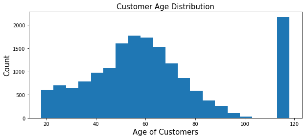

```python
plt.figure(figsize=(10, 4))

# Age distribution
plt.hist(profile['age'], bins = 20);
plt.xlabel('Age of Customers',fontdict={'fontsize':15});
plt.ylabel('Count',fontdict={'fontsize':15});
plt.title('Customer Age Distribution',fontdict={'fontsize':15});
```

From the above histogram we can see that mostly our customers have ages between 40 to around 80,also there is a outlier which is around 120,It is fault and the median is around 60.

#### 3.What is the values in the Income?What is median?

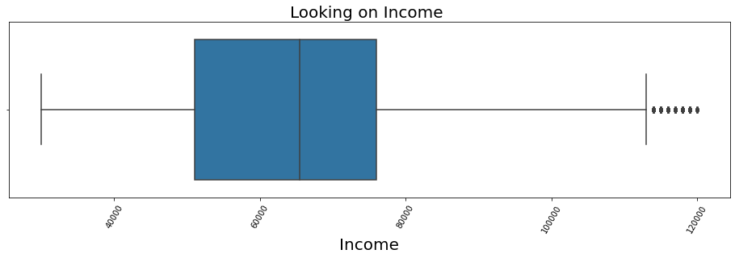

```python
plt.figure(figsize=(16, 4))
sns.boxplot(profile['income'])
plt.title('Looking on Income ',fontdict={'fontsize':20})
plt.xlabel('Income',fontdict={'fontsize':20})
plt.xticks(rotation = 60)
plt.show();
```

Our boxplot shows that most of incomes falls between 50k and 78k and the median is around 65k.

#### 4.What is the number of profiles in each month?

```python
profile['became_member_on_month'] = profile['became_member_on'].astype(str).str[:6]
#converting into string
```

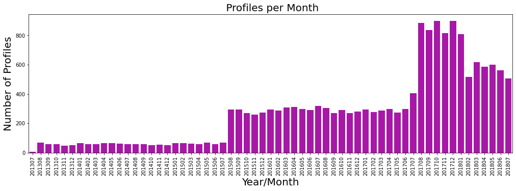

```python
plt.figure(figsize=(17, 5))
sns.countplot(profile['became_member_on_month'],color='m')
plt.title(' Profiles per Month',fontdict={'fontsize':20})
plt.ylabel('Number of Profiles',fontdict={'fontsize':20})
plt.xlabel('Year/Month',fontdict={'fontsize':20})
plt.xticks(rotation = 90)
plt.show()
```

We can see that we did better job between August 2017 and January 2018.

#### 5.What are the number of events in Transcripts?

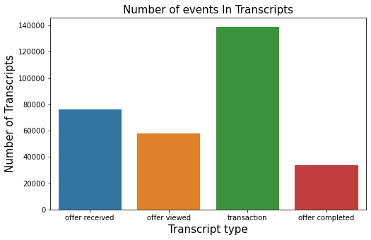

```python
plt.figure(figsize=(8, 5))
sns.countplot(transcript['event'])
plt.title('Number of events In Transcripts',fontdict={'fontsize':15})
plt.ylabel('Number of Transcripts',fontdict={'fontsize':15})
plt.xlabel('Transcript type',fontdict={'fontsize':15})
#plt.xticks(rotation = 0)
plt.show()
```

#### 6.What is the average mean and ages of Starbucks Customers?

```python
print("The mean of income is:",profile['income'].describe()['mean'])
print("The mean of age is:",profile['age'].describe()['mean'])
```

```
The mean of income is: 65404.99156829799
The mean of age is: 62.53141176470588
```

#### 7.What are the number of offer completed for each offer?

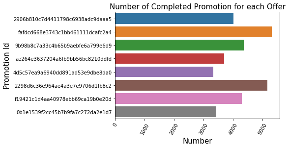

```python
completed_count = transcript[transcript['event'] == 'offer completed']

sns.countplot(y=completed_count['offer_id'])
plt.title('Number of Completed Promotion for each Offer',fontdict={'fontsize':15})
plt.ylabel('Promotion Id',fontdict={'fontsize':15})
plt.xticks(rotation = 60)
plt.xlabel('Number',fontdict={'fontsize':15})
plt.show()
```

Offer ID: fafdcd668e3743c1bb461111dcafc2a4 has been completed mostly.

#### 8. What is the minimum common promotion?

```python
print(f'Offer ID: {completed_count["offer_id"].value_counts().index[-1]}')
print(f'Number of Completion: {completed_count["offer_id"].value_counts().values[-1]}')
```

```
Offer ID: 4d5c57ea9a6940dd891ad53e9dbe8da0
Number of Completion: 3331
```

#### 9.Which customers get more income male or female?

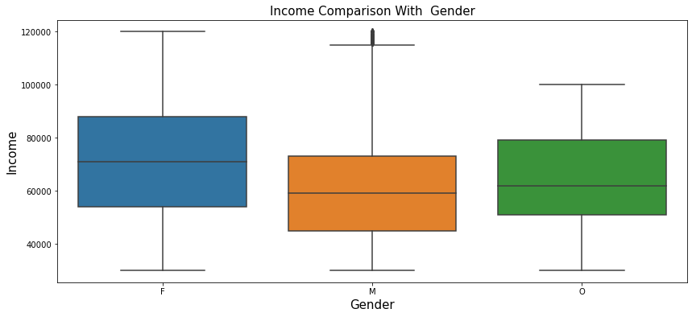

```python
plt.figure(figsize=(14, 6))
sns.boxplot(x=profile[profile['gender'] != 'NA']['gender'], y=profile['income'])
plt.title('Income Comparison With  Gender',fontdict={'fontsize':15})
plt.ylabel('Income',fontdict={'fontsize':15})
plt.xlabel('Gender',fontdict={'fontsize':15})
plt.show()
```

From the above boxplot we can see that,Female earns more than males,Median of female is around 70k while male is 60k,I have ignored those have not mentioned their gender.

#### 10.What is the gender distribution in the transcript dataframe?

I am creating a function so that a new column of gender is created in transcript data .

```python
def get_thecustomers_gender(profile_id):
    gender = profile[profile['id'] == profile_id]['gender'].values[0]
    return gender

transcript['gender'] = transcript.apply(lambda x: get_thecustomers_gender(x['person']), axis=1)
```

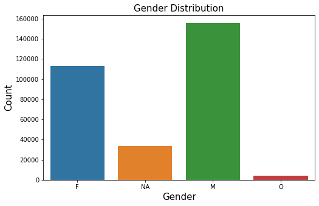

```python
plt.figure(figsize=(8, 5))
sns.countplot(transcript['gender'])
plt.title('Gender Distribution',fontdict={'fontsize':15})
plt.ylabel('Count',fontdict={'fontsize':15})
plt.xlabel('Gender',fontdict={'fontsize':15})
plt.xticks(rotation = 0)
plt.show()
```

There are more Males than females

#### 11.What are the distributions to each gender in offer Event?

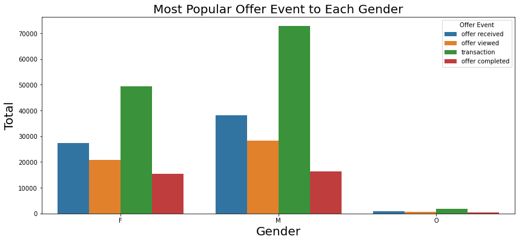

```python
plt.figure(figsize=(14, 6))
sns.countplot(x=transcript[transcript["gender"] != 'NA']['gender'], hue="event", data=transcript)
plt.title('Most Popular Offer Event to Each Gender',fontdict={'fontsize':20}  )
plt.ylabel('Total',fontdict={'fontsize':20})
plt.xlabel('Gender',fontdict={'fontsize':20})
plt.xticks(rotation = 0)
plt.legend(title='Offer Event')
plt.show();
```

#### 12.What is the distribution of events in Transcripts?

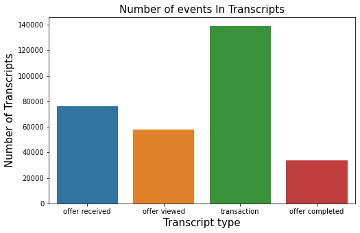

```python
plt.figure(figsize=(8, 5))
sns.countplot(transcript['event'])
plt.title('Number of events In Transcripts',fontdict={'fontsize':15})
plt.ylabel('Number of Transcripts',fontdict={'fontsize':15})
plt.xlabel('Transcript type',fontdict={'fontsize':15})
plt.xticks(rotation = 0)
plt.show();
```

From the above plot we can see that nearly half of the offer is being completed.

#### 13.What is the distribution of Offers ?

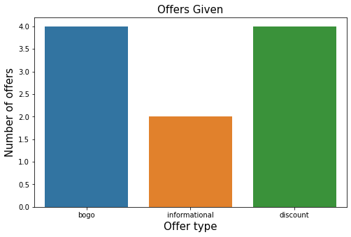

```python
plt.figure(figsize=(8, 5))
sns.countplot(portfolio['offer_type'])
plt.title('Offers Given',fontdict={'fontsize':15})
plt.ylabel('Number of offers',fontdict={'fontsize':15})
plt.xlabel('Offer type',fontdict={'fontsize':15})
plt.xticks(rotation = 0)
plt.show()
```

```python
portfolio['offer_type'].value_counts()
```

```
bogo             4
discount         4
informational    2
Name: offer_type, dtype: int64
```

From the above plot we can see that bogo and discount are the most offers given and in a almost equal proportion.

```python
transcript.sample(6)
```

|  | person | event | time | offer_id | amount | reward | gender |
| --- | --- | --- | --- | --- | --- | --- | --- |
| 299900 | 7a3f7b744de042fbadf2fe7f72619bda | transaction | 684 |  | 0 | 0 | M |
| 297231 | d0364573196344df9de76b5a5ddbf6bc | offer completed | 672 | 2906b810c7d4411798c6938adc9daaa5 | 0 | 2 | F |
| 280842 | 9bc7ee251eec46ffaf81c1906792bef6 | transaction | 618 |  | 3 | 0 | M |
| 226283 | 089d00cfd1fc45258ce97ebd2e4779f8 | transaction | 522 |  | 11 | 0 | F |
| 262821 | 3282a2d093e040ac9250233349c9888c | offer viewed | 582 | 2298d6c36e964ae4a3e7e9706d1fb8c2 | 0 | 0 | F |
| 79597 | 6c0bf1e9a354447689cac11e0e239ea0 | transaction | 198 |  | 1 | 0 | NA |

#### 14. Which Offer Id is given maximum times in gender?

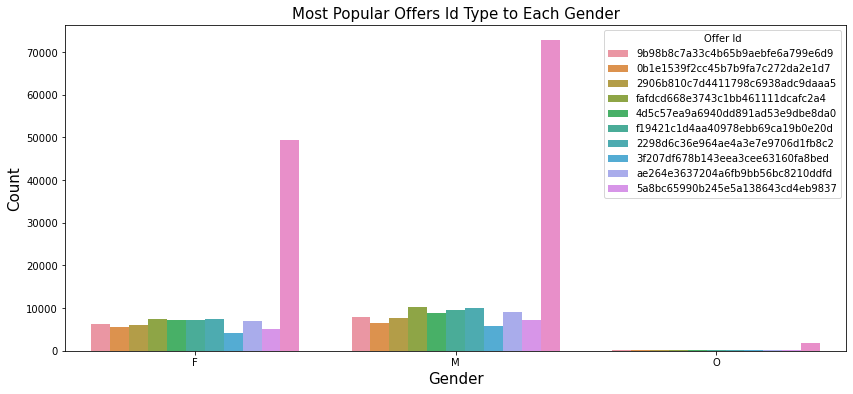

```python
plt.figure(figsize=(14, 6))
sns.countplot(x=transcript[transcript['gender'] != 'NA']['gender'], hue="offer_id", data=transcript)
plt.title('Most Popular Offers Id Type to Each Gender',fontdict={'fontsize':15})
plt.ylabel('Count',fontdict={'fontsize':15})
plt.xlabel('Gender',fontdict={'fontsize':15})
plt.xticks(rotation = 0)
plt.legend(title='Offer Id')
plt.show()
```

```python
print(list(transcript['offer_id']).count('5a8bc65990b245e5a138643cd4eb9837'))
print(list(transcript['offer_id']).count('9b98b8c7a33c4b65b9aebfe6a799e6d9'))
```

```
14305
16202
```

```python
average_f = transcript.groupby(['gender', 'offer_id'])['time'].mean().reset_index()
average_m = transcript.groupby(['gender', 'offer_id'])['time'].mean().reset_index()
average_f  = average_f [average_f ['offer_id'] == '']
average_m = average_m[average_m['offer_id'] == '']
print(average_f[average_f['gender'] == 'F']['time'].values[0], average_f[average_f['gender'] == 'F']['time'].values[0] / 24)
print(average_f[average_f['gender'] == 'M']['time'].values[0], average_f[average_f['gender'] == 'M']['time'].values[0] / 24)
```

```
380.8600299704346 15.869167915434774
381.72731269060637 15.905304695441933
```

```python
def obtain_offer_type(offer_id):
    try:
        offer_type = portfolio[portfolio['id'] == offer_id]['offer_type'].values[0]
        return offer_type
    except:
        offer_type = 'NA'
        return offer_type

transcript['offer_type'] = transcript.apply(lambda x: obtain_offer_type(x['offer_id']), axis=1)
```

```python
transcript.head()
```

|  | person | event | time | offer_id | amount | reward | gender | offer_type |
| --- | --- | --- | --- | --- | --- | --- | --- | --- |
| 0 | 78afa995795e4d85b5d9ceeca43f5fef | offer received | 0 | 9b98b8c7a33c4b65b9aebfe6a799e6d9 | 0 | 0 | F | bogo |
| 1 | a03223e636434f42ac4c3df47e8bac43 | offer received | 0 | 0b1e1539f2cc45b7b9fa7c272da2e1d7 | 0 | 0 | NA | discount |
| 2 | e2127556f4f64592b11af22de27a7932 | offer received | 0 | 2906b810c7d4411798c6938adc9daaa5 | 0 | 0 | M | discount |
| 3 | 8ec6ce2a7e7949b1bf142def7d0e0586 | offer received | 0 | fafdcd668e3743c1bb461111dcafc2a4 | 0 | 0 | NA | discount |
| 4 | 68617ca6246f4fbc85e91a2a49552598 | offer received | 0 | 4d5c57ea9a6940dd891ad53e9dbe8da0 | 0 | 0 | NA | bogo |

#### 16. What types of offer is given to Each gender?

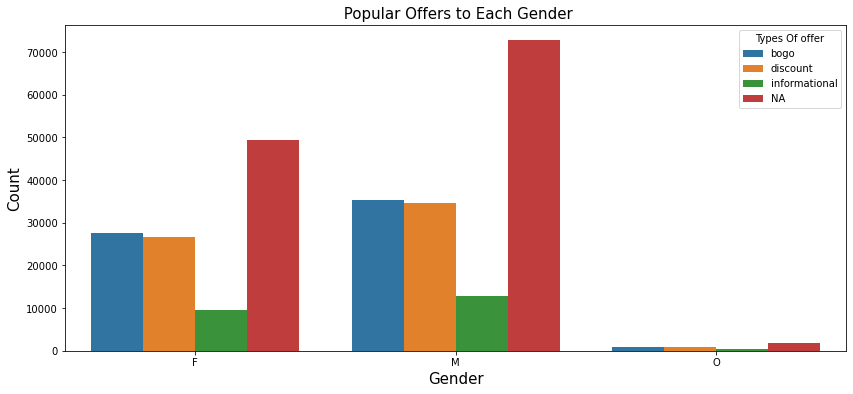

```python
plt.figure(figsize=(14, 6))
sns.countplot(x=transcript[transcript["gender"] != 'NA']['gender'], hue="offer_type", data=transcript)
plt.title(' Popular Offers to Each Gender',fontdict={'fontsize':15})
plt.ylabel('Count',fontdict={'fontsize':15})
plt.xlabel('Gender',fontdict={'fontsize':15})
plt.xticks(rotation = 0)
plt.legend(title='Types Of offer')
plt.show()
```

```python
transcript['offer_type'].groupby(transcript['gender']).value_counts()
```

```
gender  offer_type
F       NA               49382
        bogo             27619
        discount         26652
        informational     9448
M       NA               72794
        bogo             35301
        discount         34739
        informational    12856
NA      NA               14996
        bogo              7783
        discount          7587
        informational     3406
O       NA                1781
        discount           920
        bogo               914
        informational      356
Name: offer_type, dtype: int64
```

From the above visualization I can see that all the offers are given nearly in same proportion to each gender but males have recieved more offers.

## Conclusion

In this project, I tried to analyze and find out which is the best offer to give a Starbucks customer ,how is the offer being completed and who are completing more fastly. The starting point of my project is to explore the data and look after the changes I have to make in the dataset for my further analysis.I started to find out the variables in my data then I looked after my customer ages to find that which group of ages are mostly my customers so I can further look to give offers based on that.

Then I looked on the income to find that how should the price be kept for offers so that our customers do not feel its very costly according to their income. Further I did more analysis to find something relevant about the offers ,In the analysis I found that BOGO(Buy One Get One) and Discount offers were the favourite in both the genders.

In the period of August to January there were more profiles ,so company should be more active in giving offers for profit increase.

So In a nutshell ,the company should increment offers to females than males and also BOGO and discount are the offers which attract customers most and hence they will help the company and customer will buy more .

### Further Improvement

Many further applications and improvements can be made:

The offers can be based on customers average transaction amount. If any customer have high average amount,then the offers can be given of lower duration so that they can complete more offers and increase the profit of company. And we can recommend offers with more time who have low average income,so that they can also enjoy the leverage and get attracted.

Also If a member is going in long term then we should switch offers and provide him/her more different offers so that he/her does not get bored and also he/she will recommend to it's family,friends etc.

We can add ratings to our offers to know about our offers which was liked most .